# Churchill vs. Granizado: Análisis de Encuesta GAP

En GAP nos hacemos preguntas importantes, como ¿cuál es la verdadera diferencia entre un churchill y granizado? ¿es lo suficientemente distinto el segundo del primero, o son esencialmente lo mismo? La documentación existente es insuficiente, con conflictos en la lista de ingredientes, la diferencia con el concepto de granizado, y pocas fuentes de información. Es por esto que nos dimos a la tarea de realizar una encuesta interna con la cual pudiéramos realizar un análisis objetivo y cuantitativo de la percepción pública de estos postres.

Este documento representa el análisis de los resultados de dicha encuesta.

## Imports

```python
# Exploración y preparación de datos
import pandas as pd
import numpy as np

# Visualización
import seaborn as sns
import matplotlib.pyplot as plt

# Aprendizaje de Máquina
import sklearn
```

## Ingestión de datos

El archivo de respuestas puede descargarse desde Google Sheets en forma de CSV, un formato que pandas puede ingerir sin problemas:

```python
# Ingerimos el archivo de respuestas
churchill_df = pd.read_csv("churchill.csv")

# Imprimimos las primeras observaciones:
churchill_df.head()
```

|  | Timestamp | ¿Es usted residente de Costa Rica o ha residido al menos 1 año en el país? | ¿Ha consumido usted productos descritos como "granizado" y "churchill" en momentos diferentes de su vida? | ¿Considera usted que un churchill y un granizado son dos productos diferentes? | A continuación, seleccione los ingredientes que considera son parte de un granizado: | A continuación, seleccione los ingredientes que considera son parte de un churchill: | ¿Considera usted que aparte de los ingredientes, existe alguna otra diferencia entre un churchill y un granizado? De ser así, descríbala en este campo. |
| --- | --- | --- | --- | --- | --- | --- | --- |
| 0 | 7/9/2019 9:28:08 | Si | No | Si | Hielo, Sirope, Leche Condensada, Leche en Polvo | Nunca he comido un churchill | Ni idea |
| 1 | 7/9/2019 9:30:04 | Si | Si | Si | Hielo, Sirope, Leche Condensada, Leche en Polvo | Hielo, Sirope, Leche Condensada, Leche en Polv... | No :) |
| 2 | 7/9/2019 9:30:27 | Si | Si | Si | Hielo, Sirope, Leche, Leche Condensada, Leche ... | Hielo, Sirope, Leche, Leche Condensada, Leche ... | mas leche condensada |
| 3 | 7/9/2019 9:30:38 | Si | Si | No | Hielo, Sirope, Leche Condensada, Leche en Polvo | Hielo, Sirope, Leche Condensada, Leche en Polvo | No hay diferencias entre uno y otro. |
| 4 | 7/9/2019 9:33:56 | Si | Si | Si | Hielo, Sirope, Leche Condensada, Leche en Polvo | Hielo, Sirope, Leche, Leche Condensada, Leche ... | No :D |

## Transformaciones/Limpieza

1. Renombrar las columnas para que sean fáciles de referenciar.
2. Extraer los ingredientes para granizados y churchill en columnas individuales.
3. Agrupar ingredientes extra en "otros".
4. Crear un dataset de observaciones de tipo churchill y tipo granizado.
5. Rankear correlaciones entre ingredientes y tipos.

```python
cols = ["timestamp", "es_tico", "ha_consumido", "diferentes", "ing_granizado", "ing_churchill", "comentarios"]

churchill_df.columns = cols

# Verificamos resultado
churchill_df.head()
```

|  | timestamp | es_tico | ha_consumido | diferentes | ing_granizado | ing_churchill | comentarios |
| --- | --- | --- | --- | --- | --- | --- | --- |
| 0 | 7/9/2019 9:28:08 | Si | No | Si | Hielo, Sirope, Leche Condensada, Leche en Polvo | Nunca he comido un churchill | Ni idea |
| 1 | 7/9/2019 9:30:04 | Si | Si | Si | Hielo, Sirope, Leche Condensada, Leche en Polvo | Hielo, Sirope, Leche Condensada, Leche en Polv... | No :) |
| 2 | 7/9/2019 9:30:27 | Si | Si | Si | Hielo, Sirope, Leche, Leche Condensada, Leche ... | Hielo, Sirope, Leche, Leche Condensada, Leche ... | mas leche condensada |
| 3 | 7/9/2019 9:30:38 | Si | Si | No | Hielo, Sirope, Leche Condensada, Leche en Polvo | Hielo, Sirope, Leche Condensada, Leche en Polvo | No hay diferencias entre uno y otro. |
| 4 | 7/9/2019 9:33:56 | Si | Si | Si | Hielo, Sirope, Leche Condensada, Leche en Polvo | Hielo, Sirope, Leche, Leche Condensada, Leche ... | No :D |

```python
# Obtener dummies para ingredientes de granizado
dummies_granizado = churchill_df['ing_granizado'].str.strip().str.get_dummies(sep=',')
# Renombrar columnas
dummies_granizado = dummies_granizado.rename(lambda x: x.strip().lower(), axis='columns')
# Agregar columna de tipo (0=granizado)
dummies_granizado["target"] = 0
# Verificar cambios:
dummies_granizado.head()
```

|  | frutas | helado | leche | leche condensada | leche en polvo | sirope | hielo | target |
| --- | --- | --- | --- | --- | --- | --- | --- | --- |
| 0 | 0 | 0 | 0 | 1 | 1 | 1 | 1 | 0 |
| 1 | 0 | 0 | 0 | 1 | 1 | 1 | 1 | 0 |
| 2 | 1 | 1 | 1 | 1 | 1 | 1 | 1 | 0 |
| 3 | 0 | 0 | 0 | 1 | 1 | 1 | 1 | 0 |
| 4 | 0 | 0 | 0 | 1 | 1 | 1 | 1 | 0 |

```python
# Obtener dummies para ingredientes de granizado
dummies_churchill = churchill_df['ing_churchill'].str.strip().str.get_dummies(sep=', ')
# Renombrar columnas
dummies_churchill = dummies_churchill.rename(lambda x: x.strip().lower(), axis='columns')
# Agregar columna de tipo (0=granizado)
dummies_churchill["target"] = 1
# Verificar cambios:
dummies_churchill.head()
```

|  | barquillos! | frutas | helado | hielo | la leche condensada en latita | leche | leche condensada | leche en polvo | nunca he comido un churchill | queque | sirope | creo que le ponen extras a veces | queque solo si es churchill coloso | target |
| --- | --- | --- | --- | --- | --- | --- | --- | --- | --- | --- | --- | --- | --- | --- |
| 0 | 0 | 0 | 0 | 0 | 0 | 0 | 0 | 0 | 1 | 0 | 0 | 0 | 0 | 1 |
| 1 | 0 | 0 | 1 | 1 | 0 | 0 | 1 | 1 | 0 | 0 | 1 | 0 | 0 | 1 |
| 2 | 0 | 0 | 1 | 1 | 0 | 1 | 1 | 1 | 0 | 0 | 1 | 0 | 0 | 1 |
| 3 | 0 | 0 | 0 | 1 | 0 | 0 | 1 | 1 | 0 | 0 | 1 | 0 | 0 | 1 |
| 4 | 0 | 1 | 1 | 1 | 0 | 1 | 1 | 1 | 0 | 0 | 1 | 0 | 0 | 1 |

```python
# Agrupamos entradas de ingredientes escritas en "otros"

# Columnas con las que nos queremos quedar
regular_cols = ["frutas", "helado", "leche", "leche condensada", "leche en polvo", "queque", "sirope", "hielo", "target"]

# Sumar "otros"
dummies_churchill_otros = dummies_churchill.drop(regular_cols, axis=1)
dummies_churchill_otros = dummies_churchill_otros.sum(axis=1)
dummies_churchill_otros.name = "otros"

# Agregar al dataframe
dummies_churchill = dummies_churchill[regular_cols].join(dummies_churchill_otros)
```

```python
# Verificamos resultado
dummies_churchill.head()
```

|  | frutas | helado | leche | leche condensada | leche en polvo | queque | sirope | hielo | target | otros |
| --- | --- | --- | --- | --- | --- | --- | --- | --- | --- | --- |
| 0 | 0 | 0 | 0 | 0 | 0 | 0 | 0 | 0 | 1 | 1 |
| 1 | 0 | 1 | 0 | 1 | 1 | 0 | 1 | 1 | 1 | 0 |
| 2 | 0 | 1 | 1 | 1 | 1 | 0 | 1 | 1 | 1 | 0 |
| 3 | 0 | 0 | 0 | 1 | 1 | 0 | 1 | 1 | 1 | 0 |
| 4 | 1 | 1 | 1 | 1 | 1 | 0 | 1 | 1 | 1 | 0 |

```python
# Unimos observaciones de churchill y granizados:

final_df = dummies_churchill.append(dummies_granizado, ignore_index=True, sort=False)
final_df.head()
```

|  | frutas | helado | leche | leche condensada | leche en polvo | queque | sirope | hielo | target | otros |
| --- | --- | --- | --- | --- | --- | --- | --- | --- | --- | --- |
| 0 | 0 | 0 | 0 | 0 | 0 | 0.0 | 0 | 0 | 1 | 1.0 |
| 1 | 0 | 1 | 0 | 1 | 1 | 0.0 | 1 | 1 | 1 | 0.0 |
| 2 | 0 | 1 | 1 | 1 | 1 | 0.0 | 1 | 1 | 1 | 0.0 |
| 3 | 0 | 0 | 0 | 1 | 1 | 0.0 | 1 | 1 | 1 | 0.0 |
| 4 | 1 | 1 | 1 | 1 | 1 | 0.0 | 1 | 1 | 1 | 0.0 |

```python
# Presencia de valores nulos en columnas de granizado:
final_df.info()
```

```
<class 'pandas.core.frame.DataFrame'>
RangeIndex: 84 entries, 0 to 83
Data columns (total 10 columns):
frutas              84 non-null int64
helado              84 non-null int64
leche               84 non-null int64
leche condensada    84 non-null int64
leche en polvo      84 non-null int64
queque              42 non-null float64
sirope              84 non-null int64
hielo               84 non-null int64
target              84 non-null int64
otros               42 non-null float64
dtypes: float64(2), int64(8)
memory usage: 6.6 KB
```

```python
# Reemplazamos NaNs con 0:

final_df = final_df.fillna(0)
```

```python
# Verificamos existencia de valores válidos en todas las columnas
final_df.info()
```

```
<class 'pandas.core.frame.DataFrame'>
RangeIndex: 84 entries, 0 to 83
Data columns (total 10 columns):
frutas              84 non-null int64
helado              84 non-null int64
leche               84 non-null int64
leche condensada    84 non-null int64
leche en polvo      84 non-null int64
queque              84 non-null float64
sirope              84 non-null int64
hielo               84 non-null int64
target              84 non-null int64
otros               84 non-null float64
dtypes: float64(2), int64(8)
memory usage: 6.6 KB
```

```python
# Reordenamos columnas para que target quede de última:
cols = ["frutas", "helado", "leche", "leche condensada", "leche en polvo", "queque", "sirope", "hielo", "otros", "target"]
final_df = final_df[cols]
```

## Visualizaciones Básicas

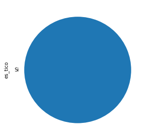

```python
# Porcentajes para respuestas sencillas:
churchill_df.groupby("es_tico")["es_tico"].count().plot(kind="pie", figsize=(5,5))
```

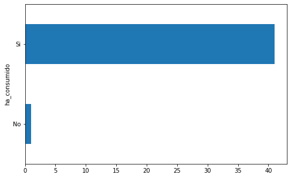

```python
# Porcentajes para respuestas sencillas:
churchill_df.groupby("ha_consumido")["ha_consumido"].count().plot(kind="barh", figsize=(8,5))
```

```python
# Tabla resumen de ingredientes
tabla_resumen = final_df.groupby("target").sum()
tabla_resumen
```

| target | frutas | helado | leche | leche condensada | leche en polvo | queque | sirope | hielo | otros |
| --- | --- | --- | --- | --- | --- | --- | --- | --- | --- |
| 0 | 2 | 3 | 9 | 39 | 40 | 0.0 | 42 | 42 | 0.0 |
| 1 | 19 | 37 | 11 | 41 | 40 | 3.0 | 40 | 39 | 5.0 |

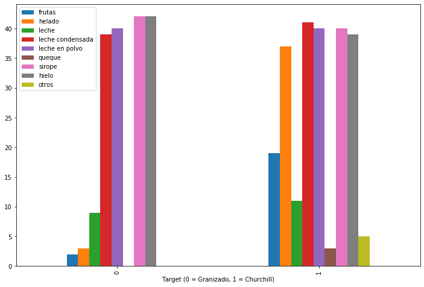

```python
# Comparativa visual:
ax = tabla_resumen.plot(kind="bar",figsize=(12,8))

ax.set_xlabel("Target (0 = Granizado, 1 = Churchill)")
```

## Análisis de Correlación:

Por medio de este análisis, buscamos establecer las variables (ingredientes) que marcan la diferencia entre un churchill y un granizado.

```python
corr = final_df.corr()
corr
```

|  | frutas | helado | leche | leche condensada | leche en polvo | queque | sirope | hielo | otros | target |
| --- | --- | --- | --- | --- | --- | --- | --- | --- | --- | --- |
| frutas | 1.000000e+00 | 0.550482 | 0.064550 | 3.296571e-16 | 4.729863e-16 | 0.185185 | -0.090167 | -0.037037 | -0.029050 | 0.467379 |
| helado | 5.504819e-01 | 1.000000 | 0.138580 | 1.012703e-01 | -1.066004e-02 | 0.201843 | -0.007445 | -0.073398 | 0.163111 | 0.810443 |
| leche | 6.454972e-02 | 0.138580 | 1.000000 | 1.250000e-01 | 1.250000e-01 | -0.107583 | 0.087304 | -0.043033 | -0.022502 | 0.055902 |
| leche condensada | 3.296571e-16 | 0.101270 | 0.125000 | 1.000000e+00 | 7.375000e-01 | 0.043033 | 0.331754 | 0.258199 | -0.180014 | 0.111803 |
| leche en polvo | 4.729863e-16 | -0.010660 | 0.125000 | 7.375000e-01 | 1.000000e+00 | 0.043033 | 0.331754 | 0.258199 | -0.180014 | 0.000000 |
| queque | 1.851852e-01 | 0.201843 | -0.107583 | 4.303315e-02 | 4.303315e-02 | 1.000000 | -0.390724 | -0.308642 | 0.222714 | 0.192450 |
| sirope | -9.016696e-02 | -0.007445 | 0.087304 | 3.317544e-01 | 3.317544e-01 | -0.390724 | 1.000000 | 0.811503 | -0.290744 | -0.156174 |
| hielo | -3.703704e-02 | -0.073398 | -0.043033 | 2.581989e-01 | 2.581989e-01 | -0.308642 | 0.811503 | 1.000000 | -0.222714 | -0.192450 |
| otros | -2.904964e-02 | 0.163111 | -0.022502 | -1.800141e-01 | -1.800141e-01 | 0.222714 | -0.290744 | -0.222714 | 1.000000 | 0.251577 |
| target | 4.673788e-01 | 0.810443 | 0.055902 | 1.118034e-01 | 0.000000e+00 | 0.192450 | -0.156174 | -0.192450 | 0.251577 | 1.000000 |

Acá nos interesa sólamente la correlación de los ingredientes con el **target**. Mientras se aproxime el índice de correlación a 1 o -1, este va a indicar una correlación positiva o negativa con el tipo de observación. Como podemos ver, la variable **helado**, con una correlación positiva de **0.81**, es la más importante.

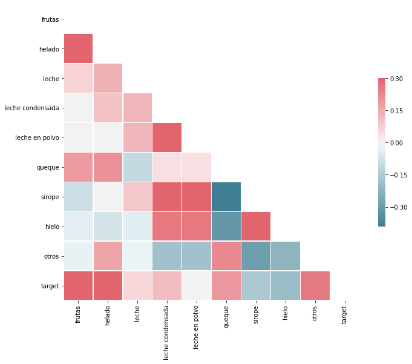

```python
mask = np.zeros_like(corr, dtype=np.bool)
mask[np.triu_indices_from(mask)] = True

f, ax = plt.subplots(figsize=(11, 9))

cmap = sns.diverging_palette(220, 10, as_cmap=True)

sns.heatmap(corr, mask=mask, cmap=cmap, vmax=.3, center=0,
            square=True, linewidths=.5, cbar_kws={"shrink": .5})
```

## Clasificador de granizado vs churchill

Construimos un árbol de decisión que clasifique observaciones en granizado a churchill basándose en sus ingredientes.

```python
# Extraemos el target del resto del dataset:

y = final_df["target"]
X = final_df.drop("target", axis=1)

X.head()
```

|  | frutas | helado | leche | leche condensada | leche en polvo | queque | sirope | hielo | otros |
| --- | --- | --- | --- | --- | --- | --- | --- | --- | --- |
| 0 | 0 | 0 | 0 | 0 | 0 | 0.0 | 0 | 0 | 1.0 |
| 1 | 0 | 1 | 0 | 1 | 1 | 0.0 | 1 | 1 | 0.0 |
| 2 | 0 | 1 | 1 | 1 | 1 | 0.0 | 1 | 1 | 0.0 |
| 3 | 0 | 0 | 0 | 1 | 1 | 0.0 | 1 | 1 | 0.0 |
| 4 | 1 | 1 | 1 | 1 | 1 | 0.0 | 1 | 1 | 0.0 |

### Separación en grupos de entrenamiento y prueba

```python
from sklearn.model_selection import train_test_split

# Generamos grupos de entrenamiento y prueba

X_train, X_test, y_train, y_test = train_test_split(X, y, test_size = 0.3, random_state = 5)
```

### Entrenamiento del modelo (Árbol de Decisión)

```python
from sklearn import tree

# Instanciación del modelo
t = tree.DecisionTreeClassifier(max_depth = 4,
                                    criterion = 'entropy',
                                    class_weight = 'balanced',
                                    random_state = 2)

# Entrenamiento
t.fit(X_train, y_train)
```

```
DecisionTreeClassifier(class_weight='balanced', criterion='entropy',
                       max_depth=4, max_features=None, max_leaf_nodes=None,
                       min_impurity_decrease=0.0, min_impurity_split=None,
                       min_samples_leaf=1, min_samples_split=2,
                       min_weight_fraction_leaf=0.0, presort=False,
                       random_state=2, splitter='best')
```

### Evaluación

```python
# Prueba
t.score(X_test, y_test)
```

```
0.9615384615384616
```

**Conclusión:** Hemos generado un modelo capaz de detectar si una observación es un granizado o un churchill con un **96% de precisión**.

## Visualización del modelo

```python
from sklearn.tree import export_graphviz
import graphviz
import pydotplus

# Generamos la visualización, exportada a un archivo .dot
dot_data = export_graphviz(t, out_file=None,
                         feature_names=X.columns,
                         class_names=["granizado", "churchill"],
                         filled=True, rounded=True,
                         special_characters=True)

# Generamos la imagen a partir del archivo .dot
pydot_graph = pydotplus.graph_from_dot_data(dot_data)
pydot_graph.set_size('"8,8!"')
pydot_graph.write_png('resized_tree.png')

gvz_graph = graphviz.Source(pydot_graph.to_string())
gvz_graph
```

[figure not shown]

# Conclusiones:

## Trabajo futuro:

- Incrementar el tamaño de la muestra.
- Probar distintos tipos de modelos de clasificación.
- Incorporar diferentes diferenciadores (ubicación geográfica, contenedor del producto).

## Créditos:

La investigación descrita en este documento fue ideada, elaborada y ejecutada por el Acxiom team de GAP.